# Optimal Treatment Analysis

## Outcome Variable

**Outcome Variable:** haz

## Predictor Variables

**Intervention Variable:** hdlvry

**Adjustment Set:**

- arm
- sex
- W_mage
- meducyrs
- W_nrooms
- brthmon
- W_parity
- impsan
- delta_W_mage
- delta_meducyrs
- delta_W_nrooms
- delta_brthmon
- delta_W_parity
- delta_impsan

## Stratifying Variables

The analysis was stratified on these variable(s):

- agecat
- studyid
- country

## Data Summary

| agecat | studyid | country | hdlvry | n_cell | n |
| --- | --- | --- | --- | --- | --- |
| Birth | ki1000108-CMC-V-BCS-2002 | INDIA | 0 | 90 | 90 |
| Birth | ki1000108-CMC-V-BCS-2002 | INDIA | 1 | 0 | 90 |
| Birth | ki1000108-IRC | INDIA | 0 | 381 | 388 |
| Birth | ki1000108-IRC | INDIA | 1 | 7 | 388 |
| Birth | ki1000109-EE | PAKISTAN | 0 | 2 | 2 |
| Birth | ki1000109-EE | PAKISTAN | 1 | 0 | 2 |
| Birth | ki1000304b-SAS-CompFeed | INDIA | 0 | 11 | 180 |
| Birth | ki1000304b-SAS-CompFeed | INDIA | 1 | 169 | 180 |
| Birth | ki1017093c-NIH-Crypto | BANGLADESH | 0 | 22 | 27 |
| Birth | ki1017093c-NIH-Crypto | BANGLADESH | 1 | 5 | 27 |
| Birth | ki1135781-COHORTS | INDIA | 0 | 2938 | 4694 |
| Birth | ki1135781-COHORTS | INDIA | 1 | 1756 | 4694 |
| Birth | kiGH5241-JiVitA-3 | BANGLADESH | 0 | 11 | 300 |
| Birth | kiGH5241-JiVitA-3 | BANGLADESH | 1 | 289 | 300 |
| Birth | kiGH5241-JiVitA-4 | BANGLADESH | 0 | 47 | 820 |
| Birth | kiGH5241-JiVitA-4 | BANGLADESH | 1 | 773 | 820 |
| 6 months | ki1000108-CMC-V-BCS-2002 | INDIA | 0 | 358 | 366 |
| 6 months | ki1000108-CMC-V-BCS-2002 | INDIA | 1 | 8 | 366 |
| 6 months | ki1000108-IRC | INDIA | 0 | 399 | 407 |
| 6 months | ki1000108-IRC | INDIA | 1 | 8 | 407 |
| 6 months | ki1000109-EE | PAKISTAN | 0 | 248 | 370 |
| 6 months | ki1000109-EE | PAKISTAN | 1 | 122 | 370 |
| 6 months | ki1000304b-SAS-CompFeed | INDIA | 0 | 147 | 1091 |
| 6 months | ki1000304b-SAS-CompFeed | INDIA | 1 | 944 | 1091 |
| 6 months | ki1000304b-SAS-FoodSuppl | INDIA | 0 | 76 | 380 |
| 6 months | ki1000304b-SAS-FoodSuppl | INDIA | 1 | 304 | 380 |
| 6 months | ki1017093b-PROVIDE | BANGLADESH | 0 | 433 | 583 |
| 6 months | ki1017093b-PROVIDE | BANGLADESH | 1 | 150 | 583 |
| 6 months | ki1017093c-NIH-Crypto | BANGLADESH | 0 | 554 | 715 |
| 6 months | ki1017093c-NIH-Crypto | BANGLADESH | 1 | 161 | 715 |
| 6 months | ki1066203-TanzaniaChild2 | TANZANIA, UNITED REPUBLIC OF | 0 | 1889 | 1921 |
| 6 months | ki1066203-TanzaniaChild2 | TANZANIA, UNITED REPUBLIC OF | 1 | 32 | 1921 |
| 6 months | ki1113344-GMS-Nepal | NEPAL | 0 | 129 | 527 |
| 6 months | ki1113344-GMS-Nepal | NEPAL | 1 | 398 | 527 |
| 6 months | ki1135781-COHORTS | INDIA | 0 | 2900 | 4699 |
| 6 months | ki1135781-COHORTS | INDIA | 1 | 1799 | 4699 |
| 6 months | kiGH5241-JiVitA-3 | BANGLADESH | 0 | 39 | 332 |
| 6 months | kiGH5241-JiVitA-3 | BANGLADESH | 1 | 293 | 332 |
| 6 months | kiGH5241-JiVitA-4 | BANGLADESH | 0 | 1081 | 4038 |
| 6 months | kiGH5241-JiVitA-4 | BANGLADESH | 1 | 2957 | 4038 |
| 24 months | ki1000108-CMC-V-BCS-2002 | INDIA | 0 | 361 | 369 |
| 24 months | ki1000108-CMC-V-BCS-2002 | INDIA | 1 | 8 | 369 |
| 24 months | ki1000108-IRC | INDIA | 0 | 401 | 409 |
| 24 months | ki1000108-IRC | INDIA | 1 | 8 | 409 |
| 24 months | ki1017093b-PROVIDE | BANGLADESH | 0 | 432 | 577 |
| 24 months | ki1017093b-PROVIDE | BANGLADESH | 1 | 145 | 577 |
| 24 months | ki1017093c-NIH-Crypto | BANGLADESH | 0 | 391 | 514 |
| 24 months | ki1017093c-NIH-Crypto | BANGLADESH | 1 | 123 | 514 |
| 24 months | ki1066203-TanzaniaChild2 | TANZANIA, UNITED REPUBLIC OF | 0 | 6 | 6 |
| 24 months | ki1066203-TanzaniaChild2 | TANZANIA, UNITED REPUBLIC OF | 1 | 0 | 6 |
| 24 months | ki1113344-GMS-Nepal | NEPAL | 0 | 120 | 467 |
| 24 months | ki1113344-GMS-Nepal | NEPAL | 1 | 347 | 467 |
| 24 months | ki1135781-COHORTS | INDIA | 0 | 2233 | 3559 |
| 24 months | ki1135781-COHORTS | INDIA | 1 | 1326 | 3559 |
| 24 months | kiGH5241-JiVitA-3 | BANGLADESH | 0 | 35 | 291 |
| 24 months | kiGH5241-JiVitA-3 | BANGLADESH | 1 | 256 | 291 |
| 24 months | kiGH5241-JiVitA-4 | BANGLADESH | 0 | 1033 | 4005 |
| 24 months | kiGH5241-JiVitA-4 | BANGLADESH | 1 | 2972 | 4005 |

The following strata were considered:

- agecat: 24 months, studyid: ki1000108-CMC-V-BCS-2002, country: INDIA
- agecat: 24 months, studyid: ki1000108-IRC, country: INDIA
- agecat: 24 months, studyid: ki1017093b-PROVIDE, country: BANGLADESH
- agecat: 24 months, studyid: ki1017093c-NIH-Crypto, country: BANGLADESH
- agecat: 24 months, studyid: ki1066203-TanzaniaChild2, country: TANZANIA, UNITED REPUBLIC OF
- agecat: 24 months, studyid: ki1113344-GMS-Nepal, country: NEPAL
- agecat: 24 months, studyid: ki1135781-COHORTS, country: INDIA
- agecat: 24 months, studyid: kiGH5241-JiVitA-3, country: BANGLADESH
- agecat: 24 months, studyid: kiGH5241-JiVitA-4, country: BANGLADESH
- agecat: 6 months, studyid: ki1000108-CMC-V-BCS-2002, country: INDIA
- agecat: 6 months, studyid: ki1000108-IRC, country: INDIA
- agecat: 6 months, studyid: ki1000109-EE, country: PAKISTAN
- agecat: 6 months, studyid: ki1000304b-SAS-CompFeed, country: INDIA
- agecat: 6 months, studyid: ki1000304b-SAS-FoodSuppl, country: INDIA
- agecat: 6 months, studyid: ki1017093b-PROVIDE, country: BANGLADESH
- agecat: 6 months, studyid: ki1017093c-NIH-Crypto, country: BANGLADESH
- agecat: 6 months, studyid: ki1066203-TanzaniaChild2, country: TANZANIA, UNITED REPUBLIC OF
- agecat: 6 months, studyid: ki1113344-GMS-Nepal, country: NEPAL
- agecat: 6 months, studyid: ki1135781-COHORTS, country: INDIA
- agecat: 6 months, studyid: kiGH5241-JiVitA-3, country: BANGLADESH
- agecat: 6 months, studyid: kiGH5241-JiVitA-4, country: BANGLADESH
- agecat: Birth, studyid: ki1000108-CMC-V-BCS-2002, country: INDIA
- agecat: Birth, studyid: ki1000108-IRC, country: INDIA
- agecat: Birth, studyid: ki1000109-EE, country: PAKISTAN
- agecat: Birth, studyid: ki1000304b-SAS-CompFeed, country: INDIA
- agecat: Birth, studyid: ki1017093c-NIH-Crypto, country: BANGLADESH
- agecat: Birth, studyid: ki1135781-COHORTS, country: INDIA
- agecat: Birth, studyid: kiGH5241-JiVitA-3, country: BANGLADESH
- agecat: Birth, studyid: kiGH5241-JiVitA-4, country: BANGLADESH

### Dropped Strata

Some strata were dropped due to rare outcomes:

- agecat: Birth, studyid: ki1000108-CMC-V-BCS-2002, country: INDIA
- agecat: Birth, studyid: ki1000109-EE, country: PAKISTAN
- agecat: 24 months, studyid: ki1066203-TanzaniaChild2, country: TANZANIA, UNITED REPUBLIC OF

## Methods Detail

We’re interested in the causal parameters $E[Y_a]$ for all values of $a \in \mathcal{A}$. These parameters represent the mean outcome if, possibly contrary to fact, we intervened to set all units to have $A=a$. Under the randomization and positivity assumptions, these are identified by the statistical parameters $\psi_a=E_W[E_{Y|A,W}(Y|A=a,W)]$. In addition, we’re interested in the mean of $Y$, $E[Y]$ under no intervention (the observed mean). We will estimate these parameters by using SuperLearner to fit the relevant likelihood factors – $E_{Y|A,W}(Y|A=a,W)$ and $p(A=a|W)$, and then updating our likelihood fit using a joint TMLE.

For unadjusted analyses ($W=\{\}$), initial likelihoods were estimated using Lrnr_glm to estimate the simple $E(Y|A)$ and Lrnr_mean to estimate $p(A)$. For adjusted analyses, a small library containing Lrnr_glmnet, Lrnr_xgboost, and Lrnr_mean was used.

Having estimated these parameters, we will then use the delta method to estimate relative risks and attributable risks relative to a prespecified baseline level of $A$.

# Results Detail

## Results Plots

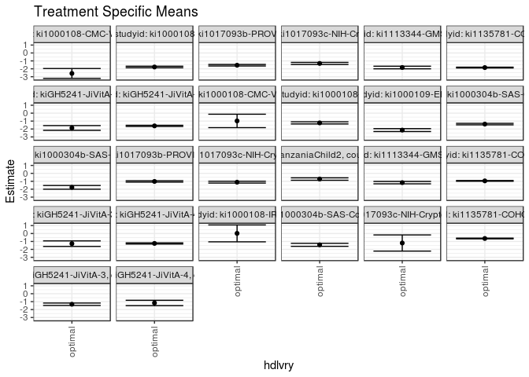

## Results Table

### Parameter: TSM

| agecat | studyid | country | intervention_level | baseline_level | estimate | ci_lower | ci_upper |
| --- | --- | --- | --- | --- | --- | --- | --- |
| Birth | ki1000108-IRC | INDIA | optimal | observed | 0.0209005 | -1.0466822 | 1.0884832 |
| Birth | ki1000304b-SAS-CompFeed | INDIA | optimal | observed | -1.4239206 | -1.6163897 | -1.2314515 |
| Birth | ki1017093c-NIH-Crypto | BANGLADESH | optimal | observed | -1.1953024 | -2.2159772 | -0.1746275 |
| Birth | ki1135781-COHORTS | INDIA | optimal | observed | -0.6260598 | -0.6706148 | -0.5815048 |
| Birth | kiGH5241-JiVitA-3 | BANGLADESH | optimal | observed | -1.3291787 | -1.4797102 | -1.1786472 |
| Birth | kiGH5241-JiVitA-4 | BANGLADESH | optimal | observed | -1.1673961 | -1.5043867 | -0.8304055 |
| 6 months | ki1000108-CMC-V-BCS-2002 | INDIA | optimal | observed | -0.9813115 | -1.8293201 | -0.1333029 |
| 6 months | ki1000108-IRC | INDIA | optimal | observed | -1.2279257 | -1.3621299 | -1.0937214 |
| 6 months | ki1000109-EE | PAKISTAN | optimal | observed | -2.1377581 | -2.3192737 | -1.9562425 |
| 6 months | ki1000304b-SAS-CompFeed | INDIA | optimal | observed | -1.3806808 | -1.4763014 | -1.2850602 |
| 6 months | ki1000304b-SAS-FoodSuppl | INDIA | optimal | observed | -1.7688852 | -2.0045445 | -1.5332260 |
| 6 months | ki1017093b-PROVIDE | BANGLADESH | optimal | observed | -1.0214285 | -1.1096385 | -0.9332184 |
| 6 months | ki1017093c-NIH-Crypto | BANGLADESH | optimal | observed | -1.1145773 | -1.2302816 | -0.9988731 |
| 6 months | ki1066203-TanzaniaChild2 | TANZANIA, UNITED REPUBLIC OF | optimal | observed | -0.7171236 | -0.8700000 | -0.5642471 |
| 6 months | ki1113344-GMS-Nepal | NEPAL | optimal | observed | -1.1714077 | -1.3225445 | -1.0202709 |
| 6 months | ki1135781-COHORTS | INDIA | optimal | observed | -0.9504153 | -0.9952439 | -0.9055868 |
| 6 months | kiGH5241-JiVitA-3 | BANGLADESH | optimal | observed | -1.2772912 | -1.6284059 | -0.9261766 |
| 6 months | kiGH5241-JiVitA-4 | BANGLADESH | optimal | observed | -1.2476437 | -1.3232592 | -1.1720282 |
| 24 months | ki1000108-CMC-V-BCS-2002 | INDIA | optimal | observed | -2.5842407 | -3.2061160 | -1.9623653 |
| 24 months | ki1000108-IRC | INDIA | optimal | observed | -1.7707852 | -1.8661983 | -1.6753721 |
| 24 months | ki1017093b-PROVIDE | BANGLADESH | optimal | observed | -1.5472565 | -1.6442792 | -1.4502338 |
| 24 months | ki1017093c-NIH-Crypto | BANGLADESH | optimal | observed | -1.3205960 | -1.4507828 | -1.1904093 |
| 24 months | ki1113344-GMS-Nepal | NEPAL | optimal | observed | -1.8358232 | -1.9990204 | -1.6726260 |
| 24 months | ki1135781-COHORTS | INDIA | optimal | observed | -1.8441370 | -1.8970333 | -1.7912407 |
| 24 months | kiGH5241-JiVitA-3 | BANGLADESH | optimal | observed | -1.8687296 | -2.1673538 | -1.5701055 |
| 24 months | kiGH5241-JiVitA-4 | BANGLADESH | optimal | observed | -1.6061763 | -1.6788526 | -1.5335000 |

### Parameter: E(Y)

| agecat | studyid | country | intervention_level | baseline_level | estimate | ci_lower | ci_upper |
| --- | --- | --- | --- | --- | --- | --- | --- |
| Birth | ki1000108-IRC | INDIA | observed | observed | -0.3080412 | -0.4687931 | -0.1472894 |
| Birth | ki1000304b-SAS-CompFeed | INDIA | observed | observed | -1.3976667 | -1.5639119 | -1.2314214 |
| Birth | ki1017093c-NIH-Crypto | BANGLADESH | observed | observed | -1.1100000 | -1.5086894 | -0.7113106 |
| Birth | ki1135781-COHORTS | INDIA | observed | observed | -0.6762420 | -0.7093108 | -0.6431732 |
| Birth | kiGH5241-JiVitA-3 | BANGLADESH | observed | observed | -1.3381333 | -1.4898513 | -1.1864153 |
| Birth | kiGH5241-JiVitA-4 | BANGLADESH | observed | observed | -1.4966707 | -1.5808284 | -1.4125130 |
| 6 months | ki1000108-CMC-V-BCS-2002 | INDIA | observed | observed | -1.4189572 | -1.5607165 | -1.2771979 |
| 6 months | ki1000108-IRC | INDIA | observed | observed | -1.2344062 | -1.3658524 | -1.1029600 |
| 6 months | ki1000109-EE | PAKISTAN | observed | observed | -2.2011622 | -2.3246467 | -2.0776776 |
| 6 months | ki1000304b-SAS-CompFeed | INDIA | observed | observed | -1.4699588 | -1.5446559 | -1.3952616 |
| 6 months | ki1000304b-SAS-FoodSuppl | INDIA | observed | observed | -1.8986842 | -2.0118892 | -1.7854792 |
| 6 months | ki1017093b-PROVIDE | BANGLADESH | observed | observed | -1.0871041 | -1.1635539 | -1.0106543 |
| 6 months | ki1017093c-NIH-Crypto | BANGLADESH | observed | observed | -1.1986783 | -1.2700937 | -1.1272630 |
| 6 months | ki1066203-TanzaniaChild2 | TANZANIA, UNITED REPUBLIC OF | observed | observed | -0.5440573 | -0.5945614 | -0.4935533 |
| 6 months | ki1113344-GMS-Nepal | NEPAL | observed | observed | -1.3111986 | -1.3908744 | -1.2315228 |
| 6 months | ki1135781-COHORTS | INDIA | observed | observed | -1.0458076 | -1.0793244 | -1.0122908 |
| 6 months | kiGH5241-JiVitA-3 | BANGLADESH | observed | observed | -1.2787349 | -1.4248268 | -1.1326431 |
| 6 months | kiGH5241-JiVitA-4 | BANGLADESH | observed | observed | -1.3481303 | -1.3904710 | -1.3057895 |
| 24 months | ki1000108-CMC-V-BCS-2002 | INDIA | observed | observed | -2.5615989 | -2.6621298 | -2.4610681 |
| 24 months | ki1000108-IRC | INDIA | observed | observed | -1.7824776 | -1.8765600 | -1.6883952 |
| 24 months | ki1017093b-PROVIDE | BANGLADESH | observed | observed | -1.5861179 | -1.6693668 | -1.5028689 |
| 24 months | ki1017093c-NIH-Crypto | BANGLADESH | observed | observed | -1.4295331 | -1.5127726 | -1.3462935 |
| 24 months | ki1113344-GMS-Nepal | NEPAL | observed | observed | -1.8686046 | -1.9550497 | -1.7821594 |
| 24 months | ki1135781-COHORTS | INDIA | observed | observed | -2.0097359 | -2.0499675 | -1.9695043 |
| 24 months | kiGH5241-JiVitA-3 | BANGLADESH | observed | observed | -2.1549141 | -2.2975185 | -2.0123097 |
| 24 months | kiGH5241-JiVitA-4 | BANGLADESH | observed | observed | -1.7500225 | -1.7884190 | -1.7116259 |

### Parameter: PAR

| agecat | studyid | country | intervention_level | baseline_level | estimate | ci_lower | ci_upper |
| --- | --- | --- | --- | --- | --- | --- | --- |
| Birth | ki1000108-IRC | INDIA | optimal | observed | -0.3289417 | -1.3825501 | 0.7246666 |
| Birth | ki1000304b-SAS-CompFeed | INDIA | optimal | observed | 0.0262539 | -0.1007241 | 0.1532319 |
| Birth | ki1017093c-NIH-Crypto | BANGLADESH | optimal | observed | 0.0853024 | -0.8545844 | 1.0251891 |
| Birth | ki1135781-COHORTS | INDIA | optimal | observed | -0.0501822 | -0.0788740 | -0.0214904 |
| Birth | kiGH5241-JiVitA-3 | BANGLADESH | optimal | observed | -0.0089546 | -0.0311681 | 0.0132588 |
| Birth | kiGH5241-JiVitA-4 | BANGLADESH | optimal | observed | -0.3292747 | -0.6594816 | 0.0009323 |
| 6 months | ki1000108-CMC-V-BCS-2002 | INDIA | optimal | observed | -0.4376457 | -1.2775663 | 0.4022748 |
| 6 months | ki1000108-IRC | INDIA | optimal | observed | -0.0064806 | -0.0193638 | 0.0064027 |
| 6 months | ki1000109-EE | PAKISTAN | optimal | observed | -0.0634040 | -0.2038192 | 0.0770111 |
| 6 months | ki1000304b-SAS-CompFeed | INDIA | optimal | observed | -0.0892779 | -0.2099935 | 0.0314376 |
| 6 months | ki1000304b-SAS-FoodSuppl | INDIA | optimal | observed | -0.1297990 | -0.3405748 | 0.0809768 |
| 6 months | ki1017093b-PROVIDE | BANGLADESH | optimal | observed | -0.0656756 | -0.1115036 | -0.0198476 |
| 6 months | ki1017093c-NIH-Crypto | BANGLADESH | optimal | observed | -0.0841010 | -0.1703364 | 0.0021344 |
| 6 months | ki1066203-TanzaniaChild2 | TANZANIA, UNITED REPUBLIC OF | optimal | observed | 0.1730662 | 0.0250347 | 0.3210978 |
| 6 months | ki1113344-GMS-Nepal | NEPAL | optimal | observed | -0.1397909 | -0.2727788 | -0.0068031 |
| 6 months | ki1135781-COHORTS | INDIA | optimal | observed | -0.0953923 | -0.1257255 | -0.0650591 |
| 6 months | kiGH5241-JiVitA-3 | BANGLADESH | optimal | observed | -0.0014437 | -0.2947072 | 0.2918198 |
| 6 months | kiGH5241-JiVitA-4 | BANGLADESH | optimal | observed | -0.1004865 | -0.1637719 | -0.0372012 |
| 24 months | ki1000108-CMC-V-BCS-2002 | INDIA | optimal | observed | 0.0226418 | -0.5907490 | 0.6360325 |
| 24 months | ki1000108-IRC | INDIA | optimal | observed | -0.0116924 | -0.0260046 | 0.0026198 |
| 24 months | ki1017093b-PROVIDE | BANGLADESH | optimal | observed | -0.0388614 | -0.0869726 | 0.0092499 |
| 24 months | ki1017093c-NIH-Crypto | BANGLADESH | optimal | observed | -0.1089370 | -0.2033855 | -0.0144886 |
| 24 months | ki1113344-GMS-Nepal | NEPAL | optimal | observed | -0.0327814 | -0.1725839 | 0.1070211 |
| 24 months | ki1135781-COHORTS | INDIA | optimal | observed | -0.1655989 | -0.2028625 | -0.1283352 |
| 24 months | kiGH5241-JiVitA-3 | BANGLADESH | optimal | observed | -0.2861845 | -0.5712356 | -0.0011334 |
| 24 months | kiGH5241-JiVitA-4 | BANGLADESH | optimal | observed | -0.1438462 | -0.2049680 | -0.0827244 |